# Boosting (and bagging)

Carsten F. Dormann

17 November, 2018

# 1 Example 1: Boosting a recursive partitioning tree

## 1.1 Fit a single tree with rpart, then boost it manually twice

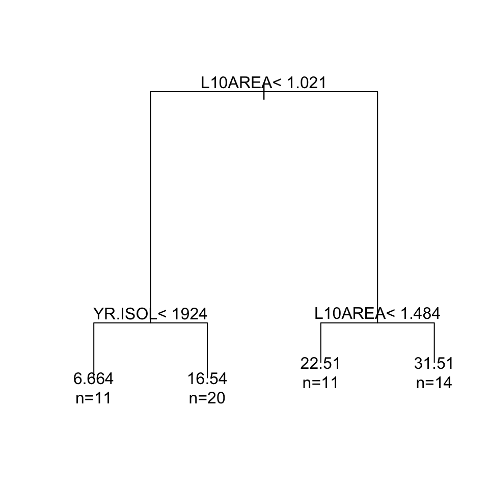

```r
loyn <- read.csv("loyn.csv")

library(rpart)
fit0 <- rpart(ABUND ~ L10AREA + L10DIST + YR.ISOL, data=loyn, control=list(maxdepth=2))
plot(fit0)
text(fit0, use.n = TRUE, xpd=T)
```

Compute predictions and residuals of this model:

```r
resids0 <- residuals(fit0)
preds0 <- predict(fit0)
w0 <- resids0^2
```

Normally we would now use fit1 as an offset in the model before fitting the next stage. This is (apparently) not possible in rpart. Instead, we can proceed on the residuals of the previous step (because data are assumed to be normally distributed) and aggregate in a second step:

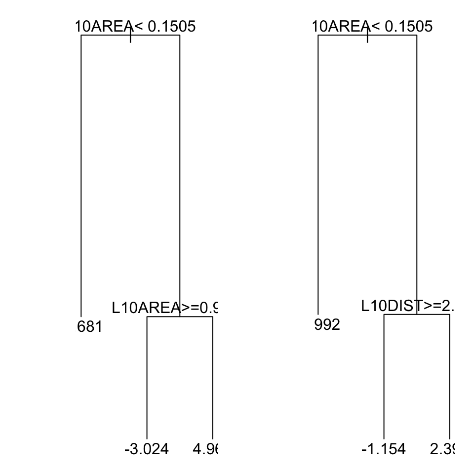

```r
w1 <- w0/sum(w0) # rescale to sum=1
fit1 <- rpart(resids0 ~ L10AREA + L10DIST + YR.ISOL, data=loyn, weights=w1, control=list(maxdepth=2))
# compare this to no weighting:
fit1noweights <- rpart(resids0 ~ L10AREA + L10DIST + YR.ISOL, data=loyn, weights=NULL, control=list(maxdepth=2))
par(mar=c(1,4,1,1), mfrow=c(1,2))
plot(fit1)
text(fit1)
plot(fit1noweights)
text(fit1noweights)
```

Now we need to combine these models in the best possible way, computing $\gamma_1$:

```r
predsResidsRegression1 <- predict(fit1)
comb1 <- lm(ABUND ~ predsResidsRegression1 -1, offset=preds0, data=loyn) # offset is like an intercept per data point
summary(comb1)
```

```
Call:
lm(formula = ABUND ~ predsResidsRegression1 - 1, data = loyn,
    offset = preds0)

Residuals:
     Min       1Q   Median       3Q      Max
-16.0488  -2.6718   0.7582   4.7323  11.8307

Coefficients:
                       Estimate Std. Error t value Pr(>|t|)
predsResidsRegression1   0.4849     0.1416   3.425  0.00117 **
---
Signif. codes:  0 '***' 0.001 '**' 0.01 '*' 0.05 '.' 0.1 ' ' 1

Residual standard error: 5.784 on 55 degrees of freedom
Multiple R-squared:  0.9287,    Adjusted R-squared:  0.9274
F-statistic: 716.7 on 1 and 55 DF,  p-value: < 2.2e-16
```

```r
gamma1 <- coef(comb1) # this is gamma1
```

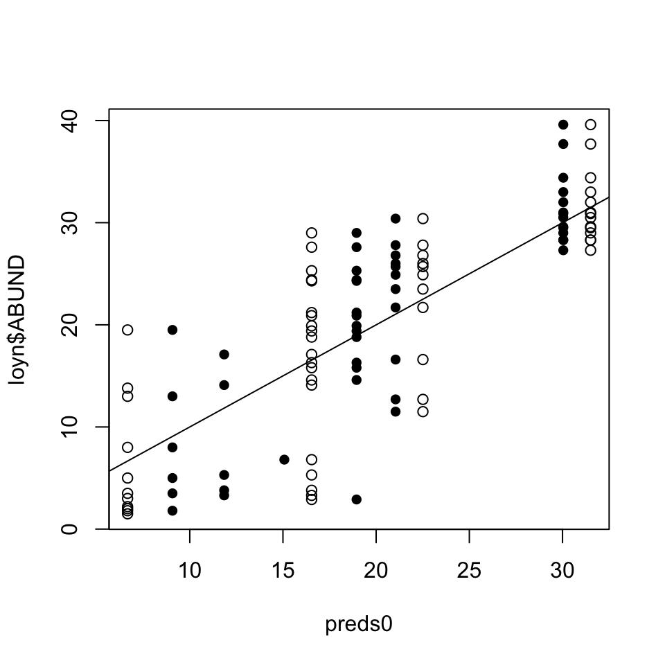

```r
preds1 <- predict(comb1)
plot(preds0, loyn$ABUND)
abline(0,1)
points(preds1, loyn$ABUND, pch=16)
```

Okay, let’s try another stage (at some point this becomes boring, since we know that there is a function to do all this for us):

```r
resids1 <- residuals(comb1)
w2 <- resids1^2
w2 <- w2/sum(w2) # rescale to sum=1
fit2 <- rpart(resids1 ~ L10AREA + L10DIST + YR.ISOL, data=loyn, weights=w2, control=list(maxdepth=2))
# estimate gamma2:
predsResidsRegression2 <- predict(fit2)
comb2 <- lm(ABUND ~ predsResidsRegression2 -1, offset=preds1, data=loyn) # offset is like an intercept per data point
(gamma2 <- coef(comb2)) # this is gamma2
```

```
predsResidsRegression2
             0.3544894
```

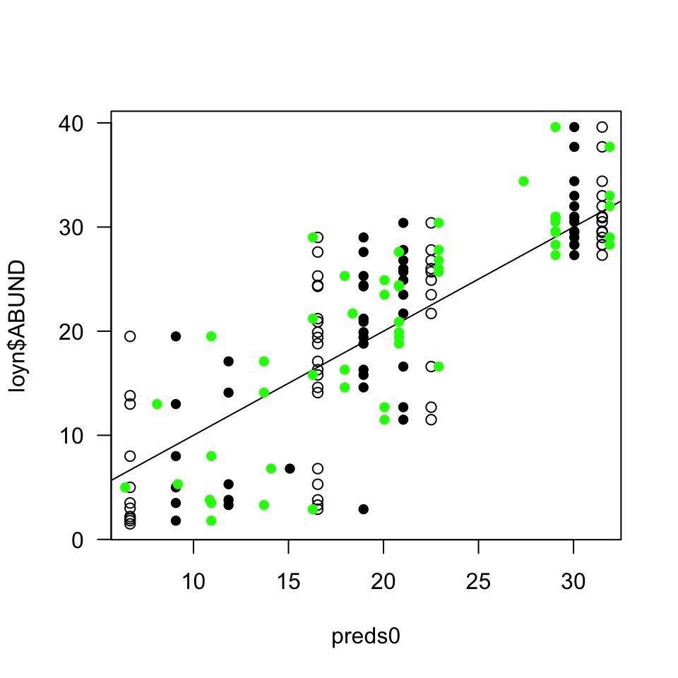

```r
preds2 <- predict(comb2)
preds1 <- predict(comb1)
plot(preds0, loyn$ABUND, las=1)
abline(0,1)
points(preds1, loyn$ABUND, pch=16)
points(preds2, loyn$ABUND, pch=16, col="green")
```

Let’s see whether the fit actually improves:

```r
cor(loyn$ABUND, preds0)
```

```
[1] 0.8048609
```

```r
cor(loyn$ABUND, preds1)
```

```
[1] 0.8459153
```

```r
cor(loyn$ABUND, preds2)
```

```
[1] 0.8622414
```

Yeah!

Now we do the same but faster and better and …

## 1.2 Boosting using gbm

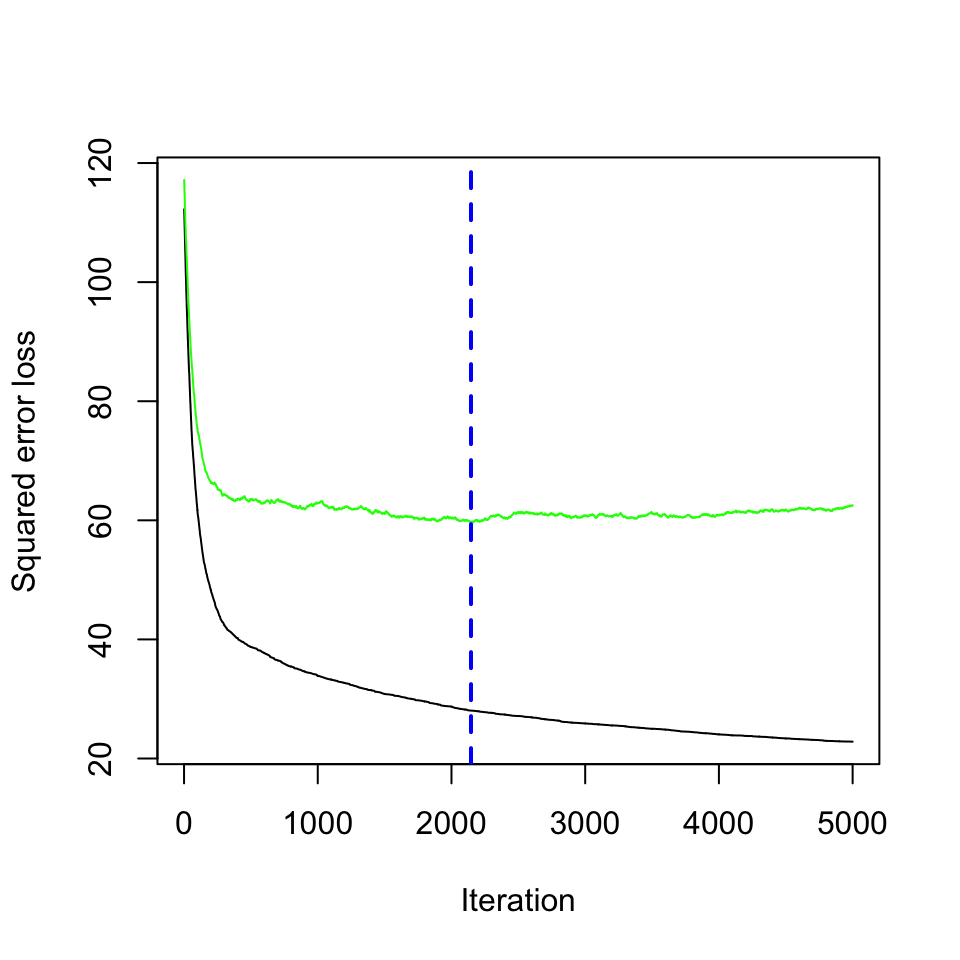

```
[1] 2146
```

```r
library(gbm)
set.seed(2)
fm.gbm <- gbm(ABUND ~ L10AREA + L10DIST + YR.ISOL, data=loyn, n.trees=5000, distribution="gaussian", interaction.depth=2, cv.folds=5, verbose=F, shrinkage=0.01)
(best.n.trees <- gbm.perf(fm.gbm, method="cv"))
```

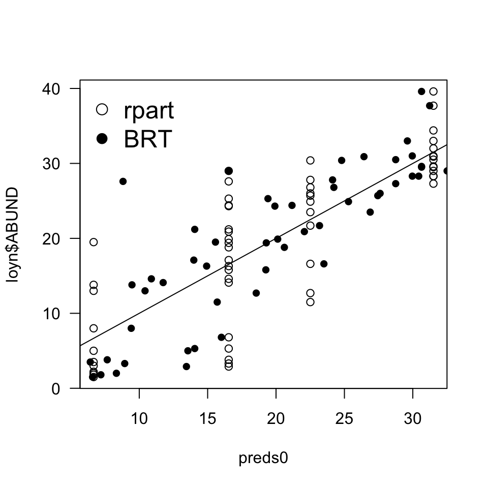

```r
preds.brt <- predict(fm.gbm, n.trees=best.n.trees)
plot(preds0, loyn$ABUND, las=1)
abline(0,1)
points(preds.brt, loyn$ABUND, pch=16)
legend("topleft", pch=c(1,16), col="black", bty="n", legend=c("rpart", "BRT"), cex=1.5)
```

```r
cor(loyn$ABUND, preds.brt)
```

```
[1] 0.8692117
```

There probably isn’t much improvement after a few hundred stages, so take the “best” number of trees with a pinch of salt.

The two main tuning parameters in BRTs are the complexity of the single tree (`interaction.depth`) and the learning rate (`shrinkage`), which pre-multiplies the “optimal” contribution of each new stage.

## 1.3 Using caret to optimise settings

```r
library(caret)
metric <- "RMSE"
trainControl <- trainControl(method="cv", number=10)
tuningGrid <- expand.grid(interaction.depth=0:5, shrinkage=c(0.001, 0.0025, 0.005, 0.01, 0.05), n.trees=5000, n.minobsinnode=10)
gbmCaretFit <- train(loyn[, c(3,8,10)], loyn$ABUND, method="gbm", tuneGrid=tuningGrid, distribution="gaussian", metric=metric, trControl=trainControl, verbose=F)
gbmCaretFit
```

```
Stochastic Gradient Boosting

56 samples
 3 predictor

No pre-processing
Resampling: Cross-Validated (10 fold)
Summary of sample sizes: 51, 51, 50, 49, 52, 51, ...
Resampling results across tuning parameters:

  shrinkage  interaction.depth  RMSE      Rsquared   MAE
  0.0010     0                       NaN        NaN       NaN
  0.0010     1                  7.277497  0.5668687  6.064850
  0.0010     2                  7.314708  0.5613965  6.103794
  0.0010     3                  7.296797  0.5632505  6.083630
  0.0010     4                  7.303803  0.5640958  6.090758
  0.0010     5                  7.285114  0.5656577  6.064230
  0.0025     0                       NaN        NaN       NaN
  0.0025     1                  7.294638  0.5774026  6.038509
  0.0025     2                  7.296601  0.5763065  6.042342
  0.0025     3                  7.301065  0.5757505  6.049976
  0.0025     4                  7.313419  0.5713754  6.031497
  0.0025     5                  7.285400  0.5762384  6.013173
  0.0050     0                       NaN        NaN       NaN
  0.0050     1                  7.454343  0.5738181  6.213360
  0.0050     2                  7.447417  0.5757828  6.194141
  0.0050     3                  7.426699  0.5751545  6.175022
  0.0050     4                  7.456768  0.5755451  6.184638
  0.0050     5                  7.434653  0.5747946  6.180953
  0.0100     0                       NaN        NaN       NaN
  0.0100     1                  7.729304  0.5576387  6.426976
  0.0100     2                  7.685537  0.5656762  6.391547
  0.0100     3                  7.784959  0.5507302  6.481599
  0.0100     4                  7.685112  0.5643546  6.407061
  0.0100     5                  7.704323  0.5555653  6.418403
  0.0500     0                       NaN        NaN       NaN
  0.0500     1                  8.747006  0.5020349  7.351464
  0.0500     2                  9.018933  0.4617087  7.599196
  0.0500     3                  8.857064  0.4822591  7.506450
  0.0500     4                  9.064949  0.4704230  7.649412
  0.0500     5                  8.873356  0.4902884  7.421030

Tuning parameter 'n.trees' was held constant at a value of 5000
Tuning parameter
 'n.minobsinnode' was held constant at a value of 10
RMSE was used to select the optimal model using the smallest value.
The final values used for the model were n.trees = 5000, interaction.depth = 1, shrinkage =
 0.001 and n.minobsinnode = 10.
```

# 2 Example 2: Bagging

## 2.1 Bagging a regression by hand

Let’s first fit a reference model:

```r
fmFull <- lm(ABUND ~ L10AREA + L10DIST + YR.ISOL, data=loyn)
```

Now we bootstrap this model, storing all bootstrapped models for later predictions (yes, I know how to do this with a function and `sapply` or parallelised, but that’s not the point here):

```r
bootedLMs <- list()
set.seed(3)
for (i in 1:100){
  bsdata <- loyn[sample(56, 56, replace=T),]
  bsfit <- lm(ABUND ~ L10AREA + L10DIST + YR.ISOL, data=bsdata)
  bootedLMs[[i]] <- bsfit
}
```

Check that it worked:

```r
sapply(bootedLMs, coef) # at least they all look different ;-)
```

[output not shown]

[output cut: 30 more lines]

```
                   [,85]        [,86]        [,87]        [,88]        [,89]        [,90]
(Intercept) -274.3661748 -269.0283431 -332.5530123 -196.4319524 -348.9366240 -402.6065020
L10AREA        8.0832559    9.4466633    8.4695823    9.3851470    7.6401396    6.3303393
L10DIST       -4.3486141    2.3698101   -5.7531302   -4.6888294    0.7803152   -6.1693735
YR.ISOL        0.1513156    0.1405399    0.1825759    0.1113365    0.1843928    0.2199253
                    [,91]        [,92]       [,93]        [,94]       [,95]        [,96]
(Intercept) -163.72836841 -365.5972850 -416.267892 -214.7400411 -205.989640 -299.0144628
L10AREA       11.06839844    7.4451744    7.330818   10.3098309    9.664865    7.0589670
L10DIST       -0.35320370   -1.4455428    3.947548   -6.5928056   -7.046630    1.0998903
YR.ISOL        0.08931082    0.1955601    0.214951    0.1227946    0.119185    0.1593859
                   [,97]        [,98]        [,99]       [,100]
(Intercept) -254.2338060 -97.16984902 -195.0217106 -249.4864510
L10AREA        8.5521670  10.82464089    9.6594292    8.3442402
L10DIST       -0.2542248  -4.08933913    2.6763853   -0.1371486
YR.ISOL        0.1364614   0.05924696    0.1027514    0.1337134
```

Now we simply predict to the original covariate combinations and average the predictions:

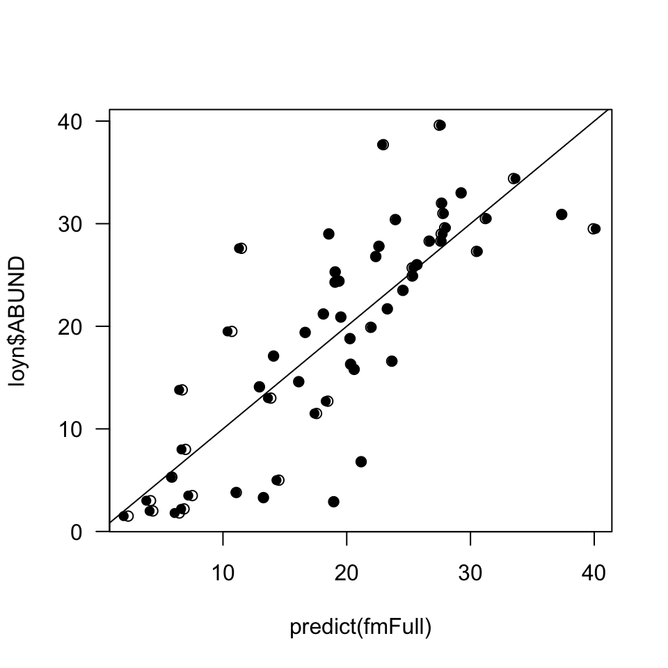

```r
predsBS <- sapply(bootedLMs, predict, newdata=loyn)
plot(predict(fmFull), loyn$ABUND, las=1)
points(rowMeans(predsBS), loyn$ABUND, pch=16)
abline(0,1)
```

```r
cor(predict(fmFull), loyn$ABUND)
```

```
[1] 0.8049667
```

```r
cor(rowMeans(predsBS), loyn$ABUND)
```

```
[1] 0.8049315
```

So clearly, this was not worth the effort! The linear model is simple “terse”, and cannot easily be improved upon.

We’ll try the same with rpart.

## 2.2 Bagging rpart

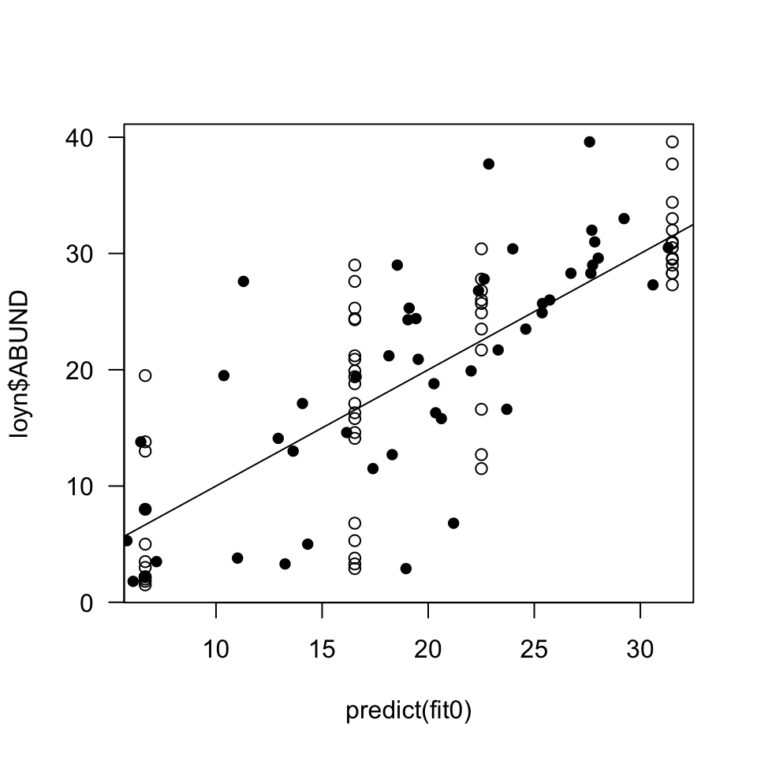

```r
bootedRparts <- list()
set.seed(4)
for (i in 1:100){
  bsdata <- loyn[sample(56, 56, replace=T),]
  bsfit <- rpart(ABUND ~ L10AREA + L10DIST + YR.ISOL, data=bsdata, control=list(maxdepth=2))
  bootedRparts[[i]] <- bsfit
}
predsBSrpart <- sapply(bootedRparts, predict, newdata=loyn)
plot(predict(fit0), loyn$ABUND, las=1)
points(rowMeans(predsBS), loyn$ABUND, pch=16)
abline(0,1)
```

```r
cor(predict(fit0), loyn$ABUND)
```

```
[1] 0.8048609
```

```r
cor(rowMeans(predsBSrpart), loyn$ABUND)
```

```
[1] 0.8520205
```

See! That does make a difference. The bagged rpart is not quite as good as the BRT, but a definite improvement over a single CART.

## 2.3 randomForest

I will spare you (and me) the attempt to inefficiently build a random forest algorithm. Here is its standard implementation:

```r
library(randomForest)
rf <- randomForest(ABUND ~ L10AREA + L10DIST + YR.ISOL, data=loyn)
rf
```

```
Call:
 randomForest(formula = ABUND ~ L10AREA + L10DIST + YR.ISOL, data = loyn)
               Type of random forest: regression
                     Number of trees: 500
No. of variables tried at each split: 1

          Mean of squared residuals: 52.68068
                    % Var explained: 53.45
```

We can now call some of the convenience functions available for assessing the importance and alike:

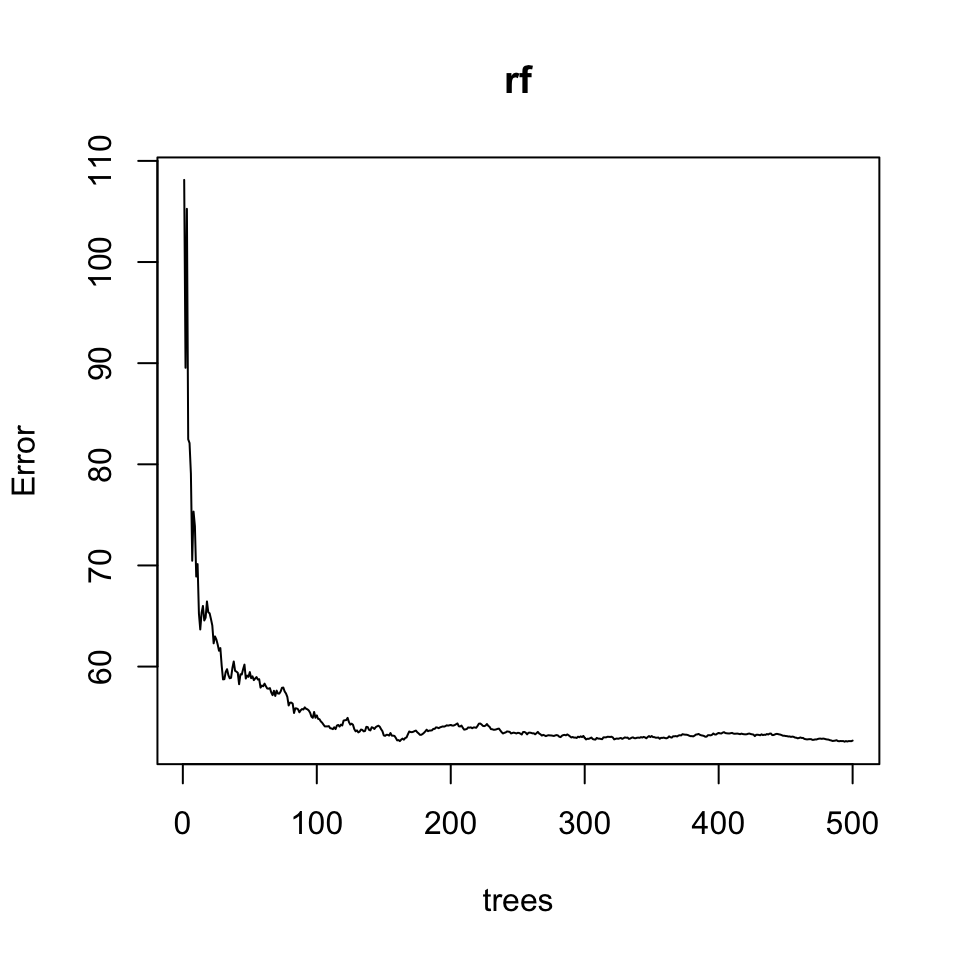

```r
plot(rf)
```

```r
randomForest::importance(rf)
```

```
        IncNodePurity
L10AREA     2719.1759
L10DIST      928.8061
YR.ISOL     1987.8999
```

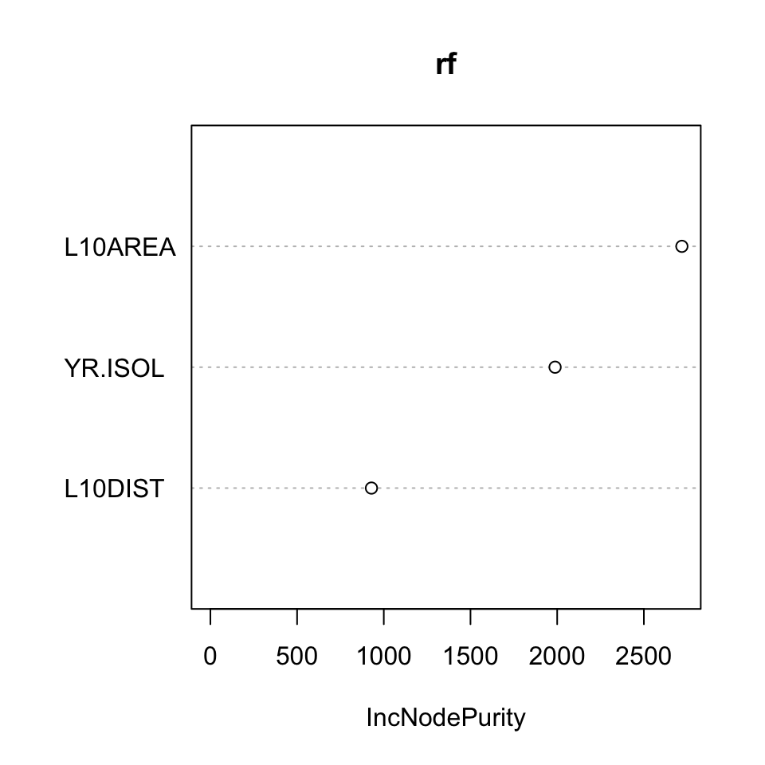

```r
varImpPlot(rf)
```

```r
cor(predict(rf, newdata=loyn), loyn$ABUND) # note that newdata is necessary, otherwise you get OOBs!
```

```
[1] 0.944182
```

We can also plot the (conditional) effects for each predictor:

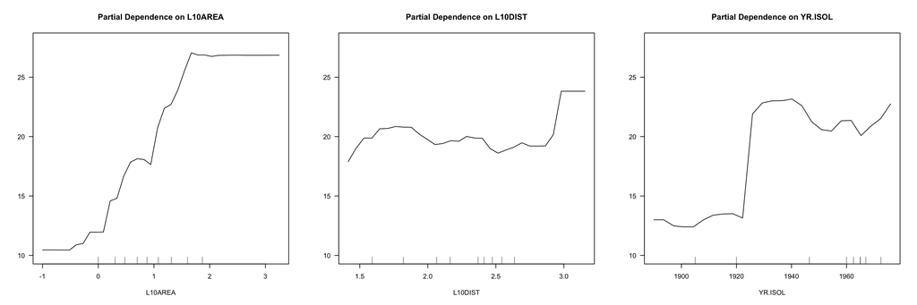

```r
par(mfrow=c(1,3), las=1)
partialPlot(rf, loyn, L10AREA, ylim=c(10,28))
partialPlot(rf, loyn, L10DIST, ylim=c(10,28))
partialPlot(rf, loyn, YR.ISOL, ylim=c(10,28))
```

We can compute prediction variance for the `randomForest` object using a different package. To do so, we need to fit `randomForest` with keepting all inbag data:

```r
devtools::install_github("swager/randomForestCI")
```

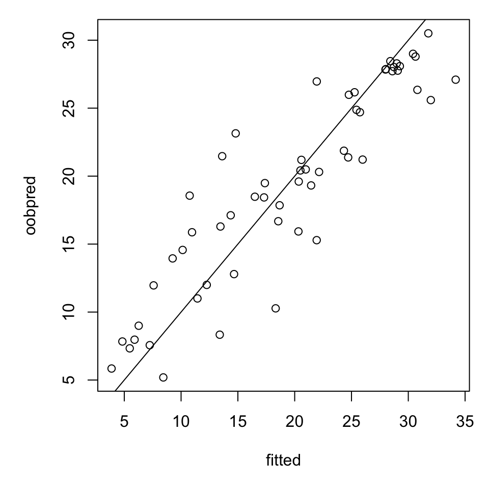

```r
library(randomForestCI)
rf2 <- randomForest(ABUND ~ L10AREA + L10DIST + YR.ISOL, data=loyn, replace=T, keep.inbag=T)

fitted <- predict(rf2, newdata=loyn)
# compare this to Out-Of-Bag predictions:
## OOB predictions are made with only those models, in which the observation was NOT used! This is akin to the jackknife idea, and should be similar to cross-validation!
oobpred <- predict(rf2) # Note different behaviour compared to GLM etc!!!
par(mar=c(5,5,1,1))
plot(fitted, oobpred)
abline(0,1)
```

```r
randomForestInfJack(rf2, newdata=data.frame(L10AREA=c(0, 0), L10DIST=2, YR.ISOL=1900)) #needs at least 2 points ...
```

```
     y.hat  var.hat
1 5.167659 2.185338
2 5.167659 2.185338
```

```r
head(randomForestInfJack(rf2, newdata=loyn)) # expectation and variance of each datum
```

```
      y.hat   var.hat
1 10.963769 12.438524
2  4.833520  4.604458
3  3.881314  2.351799
4 14.662715  2.657240
5  8.435739  6.803988
6 11.441182  2.368150
```

To compute confidence intervals, you need to take the square root of the variances (to get standard deviations), multiply them by 2 and add them to the either side of the prediction. (Note that this is the simple case of a normal response and it gets a little bit trickier with classification.)

## 2.4 Ranger

**randomForest** has been succeeded by **ranger**, which is the same but implemented in C++ and hence much faster (which you won’t notice with this kind of data size, though). It has the prediction error implemented internally.

```r
library(ranger)
franger <- ranger(ABUND ~ L10AREA + L10DIST + YR.ISOL, data=loyn, importance="impurity")
ranger::importance(franger)
```

```
  L10AREA   L10DIST   YR.ISOL
2684.6497  922.9556 2018.9008
```

```r
head(predict(franger, data=loyn)$predictions)
```

```
[1] 10.788348  4.870197  3.928583 14.588566  8.128585 11.396892
```

To compute prediction errors, we need to keep the inbag, as before for `randomForest`:

```r
franger <- ranger(ABUND ~ L10AREA + L10DIST + YR.ISOL, data=loyn, importance="impurity", keep.inbag=T)
str(predsRanger <- predict(franger, data=loyn, type="se"))
```

```
List of 6
 $ predictions              : num [1:56] 10.87 5.13 3.62 14.82 8.24 ...
 $ num.trees                : num 500
 $ num.independent.variables: num 3
 $ num.samples              : int 56
 $ treetype                 : chr "Regression"
 $ se                       : num [1:56] 3.07 2.17 1.28 1.37 2.36 ...
 - attr(*, "class")= chr "ranger.prediction"
```

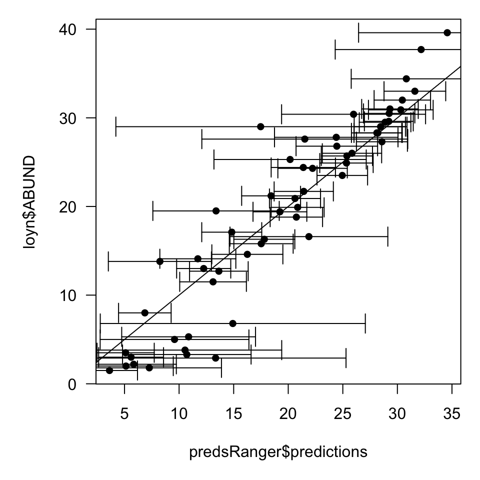

```r
par(mar=c(5,5,1,1))
plot(predsRanger$predictions, loyn$ABUND, las=1, pch=16)
abline(0,1)
arrows(x0 = predsRanger$predictions -2*predsRanger$se, y0 = loyn$ABUND, x1 = predsRanger$predictions +2*predsRanger$se, y1 = loyn$ABUND, code=3, angle=90, length=0.1)
```

This picture may sit uncomfortable with you, but it really shouldn’t! (Only if I made a mistake.)

Firstly, since we plot the expectation from the model and the observed, the observed go onto the y-axis, as they have the measurement error. Secondly, the confidence interval of each prediction is *substantial*. Of course it is: we have only 56 data points and thus we’d expect very uncertain predictions. Thirdly, notice that almost all (95%) of the confidence intervals cross the 1:1-line? That’s good! If the error bars were smaller, they would not cross the 1:1-line in the nominal 95% of cases, and then they would be wrong. Thus, when a point deviates far from the 1:1 line, it should also have a large CI, otherwise there is something wrong with the model (e.g. it is systematically biased).

Regrettably, **ranger** has no easy `partialPlot`-like command. But you can call the **pdp** package (partial dependence plotting) or you call ranger from the **caret** competitor **mlr** (machine learning in R):

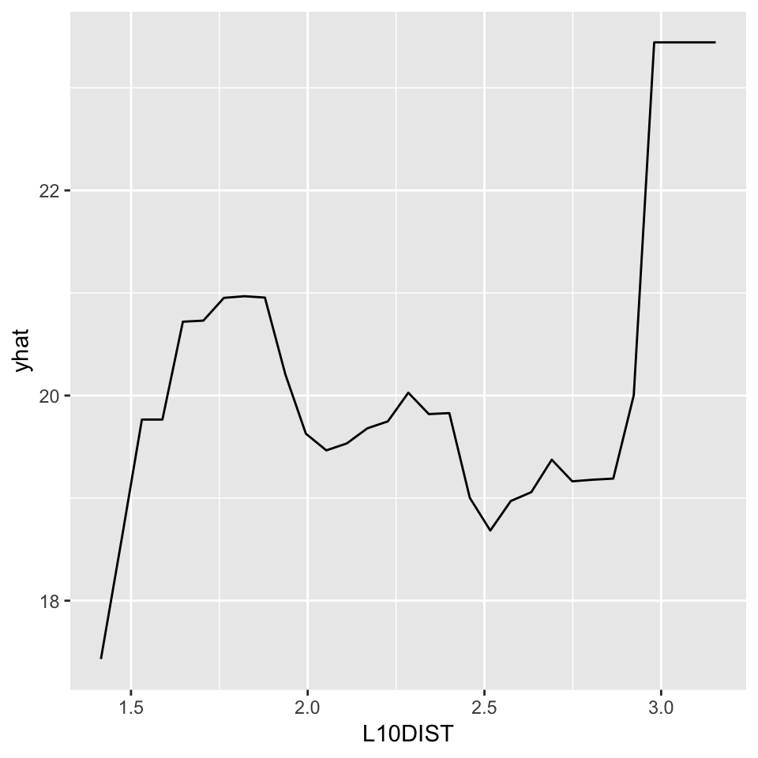

```r
library(ggplot2)
library(pdp)
pd <- partial(franger, pred.var = "L10DIST")
autoplot(pd)
```

And **mlr**:

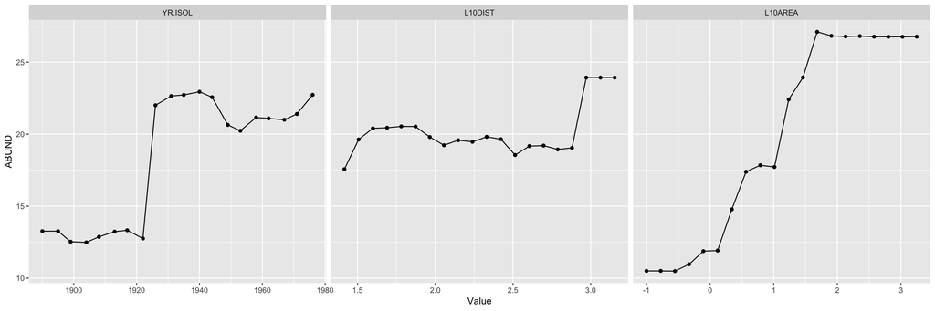

```r
library(mlr)
lrn.classif = makeLearner("regr.ranger")
# to see the full list: dplyr::View(listLearners())
loyn.task <- makeRegrTask(data=loyn[, c(1,3,8,10)], target="ABUND")
fit.classif = train(lrn.classif, loyn.task)
pd = generatePartialDependenceData(fit.classif, loyn.task, n=20)
plotPartialDependence(pd)
```

If you enjoyed this, also have a look at [this blog post](https://www.r-bloggers.com/the-tidy-caret-interface-in-r/), in which several machine learners are used simultaneously, including randomForest and boosted regression trees, using the *caret* package.